# Projet Analyse de données

Marilyne Mafo Léonard Pannetier MAIN4

Nous allons présenter ici notre projet d’analyse de données sur une base de données rassemblant de nonbreuses caractéristiques sur 20052 plats de cuisines du monde entier. Cette base publique est disponible sur Kaggle avec ce lien https://www.kaggle.com/code/upsylend/pr-diction-sur-des-recettes-de-cuisine/input.

La base possède notamment une variable rating (entre 0.0 et 5.0) représentant si un plat est apprécié/goutu, le but ce cette analyse est de prédire la valeur de la variable rating en fonction des autres variables ainsi que faire de la classification des plats afin d’en regrouper certains.

La base de données ayant beaucoup de variables, nous avons décidé de ne garder que les principales, de plus énormément de variables n’ont que 2 modalitées (comme la variable disant si oui ou non il y a du bacon dans le plat) qui vaut 1 que très rarement.

Nous ne garderons que les variables : - rating (appréciation du plat) - calories (énergie apporté par le plat) - protein (quantité de protéines) - fat (quantité de graisses) - sodium (quantité de sel) - alcoholic (0 ou 1, présence d’alcool) - bake (0 ou 1, plat rotie)

En supprimant les lignes avec au moins une valeur manquante sur ces variable nous n’avons plus que 15864 plats disponibles pour notre études.

```r
library(tidyr)
rm(list=ls())
data = read.csv("epi_r.csv", sep =",")
data = data[c(2,3,4,5,6,15,39)]
data = data[data$calories != "",]
data = data[data$protein != "",]
data = data[data$fat != "",]
data = data[data$sodium != "",]
data = drop_na(data)
head(data)
```

```
##   rating calories protein fat sodium alcoholic bake
## 1  2.500      426      30   7    559         0    0
## 2  4.375      403      18  23   1439         0    1
## 3  3.750      165       6   7    165         0    0
## 5  3.125      547      20  32    452         0    1
## 6  4.375      948      19  79   1042         0    0
## 9  4.375      170       7  10   1272         0    0
```

**Partie 1 : Statistiques descriptives**

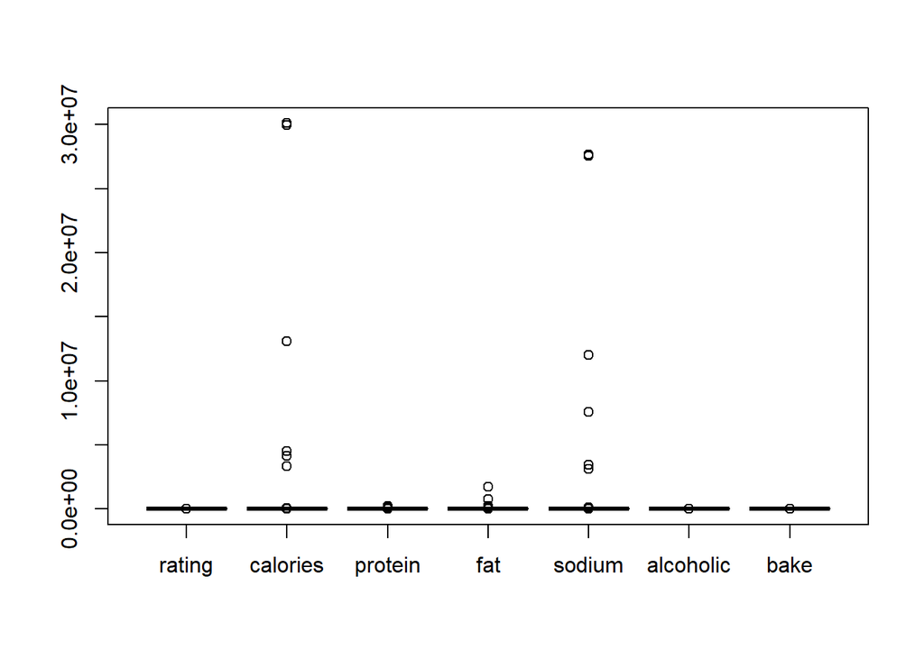

```r
boxplot(data)
```

On observe des grandes différences entre toutes nos variable, il faudra en prendre compte lors de l’analyse.

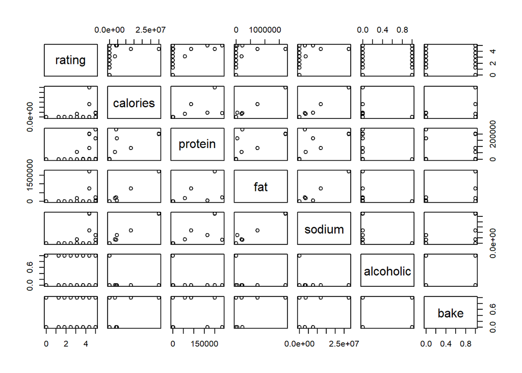

```r
pairs(data)
```

Ce diagramme permet de faire une analyse bivariée des données, si des données sont corrélées, on va observer une relation linéaires entre les deux variables.

Ainsi les variables calories et fat ont l’air d’être corrélées, ainsi que les variables calories et sodium. Nous allons vérifier cela en faisant une analyse des composantes principales (ACP).

```r
tmpData = data[c(1:250),]
library(FactoMineR)
res <- PCA(tmpData)
```

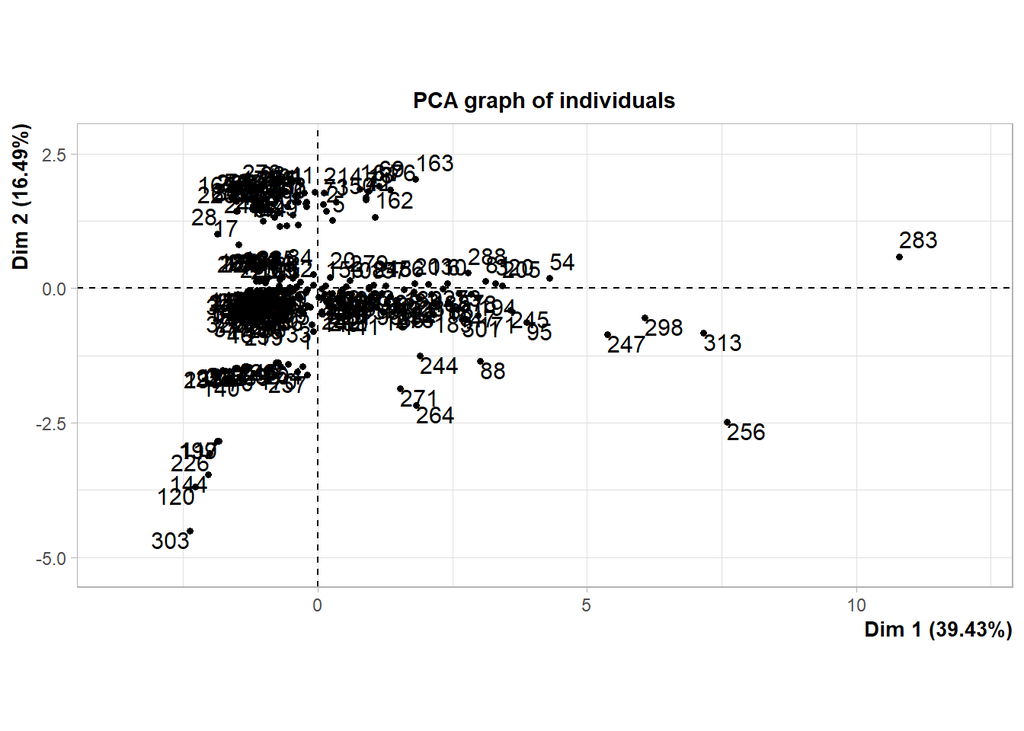

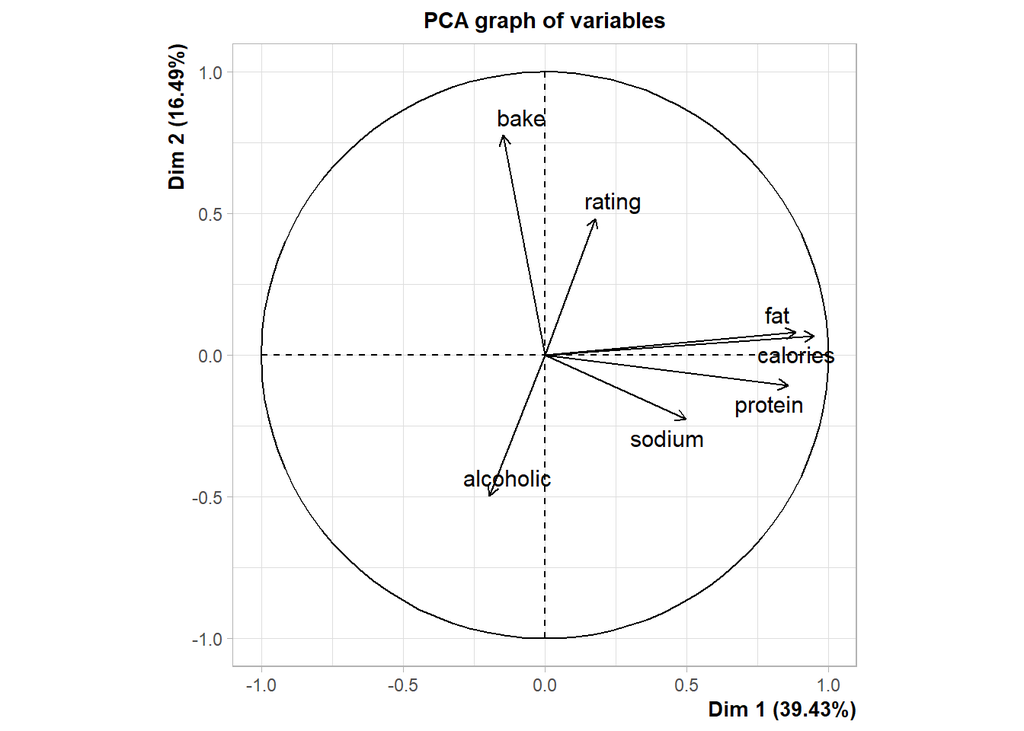

```r
res
```

```
## **Results for the Principal Component Analysis (PCA)**
## The analysis was performed on 250 individuals, described by 7 variables
## *The results are available in the following objects:
##
##    name               description
## 1  "$eig"             "eigenvalues"
## 2  "$var"             "results for the variables"
## 3  "$var$coord"       "coord. for the variables"
## 4  "$var$cor"         "correlations variables - dimensions"
## 5  "$var$cos2"        "cos2 for the variables"
## 6  "$var$contrib"     "contributions of the variables"
## 7  "$ind"             "results for the individuals"
## 8  "$ind$coord"       "coord. for the individuals"
## 9  "$ind$cos2"        "cos2 for the individuals"
## 10 "$ind$contrib"     "contributions of the individuals"
## 11 "$call"            "summary statistics"
## 12 "$call$centre"     "mean of the variables"
## 13 "$call$ecart.type" "standard error of the variables"
## 14 "$call$row.w"      "weights for the individuals"
## 15 "$call$col.w"      "weights for the variables"
```

Ici on peut interpréter le graphe des variables en disant que l’axe 1 est fortement corrélé à fat, protein et calories. Cet axe représente alors à droite les recettes les plus caloriques, salées et protéinées (c’est à dire les plats assez lourds) et à gauche celles qui ne le sont pas(les plats légers). L’axe 2 quant à lui est corrélé positivement avec les variable bake et rating et négativement avec alcoholic. On peut dire alors que cet axe distingue les recettes les mieux notées en haut (c’est à dire les plats appréciés) contre celles mal notées et alcolisées vers le bas.

Sur le graphe des individus on peut dire que la recette 283 (Ribs première braisées avec pois chiches et raisins secs) est très à droite, ainsi elle est très calorique et grasse . De plus le plat 303 (Café épicé à l’eau de vie) et en bas donc ce plat est alcoolisé et peu apprécié (il a un rating de 0).

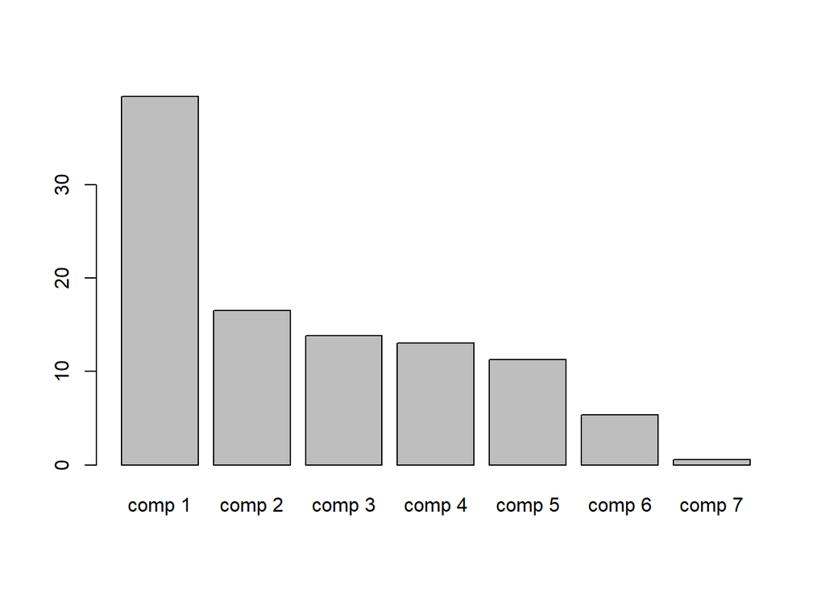

```r
barplot(res$eig[,2])
```

```r
summary(res)
```

```
##
## Call:
## PCA(X = tmpData)
##
##
## Eigenvalues
##                        Dim.1   Dim.2   Dim.3   Dim.4   Dim.5   Dim.6   Dim.7
## Variance               2.760   1.154   0.967   0.913   0.790   0.376   0.041
## % of var.             39.425  16.491  13.808  13.038  11.290   5.364   0.584
## Cumulative % of var.  39.425  55.917  69.725  82.763  94.052  99.416 100.000
##
## Individuals (the 10 first)
##               Dist    Dim.1    ctr   cos2    Dim.2    ctr   cos2    Dim.3
## 1         |  1.309 | -0.085  0.001  0.004 | -0.804  0.224  0.377 | -0.670
## 2         |  2.043 |  0.164  0.004  0.006 |  1.439  0.718  0.496 |  0.170
## 3         |  1.247 | -0.998  0.144  0.640 | -0.275  0.026  0.049 | -0.049
## 5         |  1.936 |  0.276  0.011  0.020 |  1.259  0.549  0.423 | -0.402
## 6         |  2.920 |  2.413  0.844  0.683 |  0.082  0.002  0.001 |  0.251
## 9         |  1.390 | -0.559  0.045  0.162 | -0.271  0.025  0.038 |  0.197
## 10        |  1.518 |  1.213  0.213  0.638 | -0.443  0.068  0.085 | -0.121
## 11        |  1.239 | -0.962  0.134  0.603 | -0.231  0.019  0.035 | -0.029
## 13        |  2.403 |  0.932  0.126  0.150 |  1.794  1.115  0.558 |  0.253
## 14        |  1.198 | -0.726  0.076  0.367 | -0.073  0.002  0.004 |  0.281
##              ctr   cos2
## 1          0.185  0.262 |
## 2          0.012  0.007 |
## 3          0.001  0.002 |
## 5          0.067  0.043 |
## 6          0.026  0.007 |
## 9          0.016  0.020 |
## 10         0.006  0.006 |
## 11         0.000  0.001 |
## 13         0.026  0.011 |
## 14         0.033  0.055 |
##
## Variables
##              Dim.1    ctr   cos2    Dim.2    ctr   cos2    Dim.3    ctr   cos2
## rating    |  0.179  1.157  0.032 |  0.482 20.155  0.233 |  0.700 50.710  0.490
## calories  |  0.950 32.717  0.903 |  0.069  0.409  0.005 |  0.039  0.159  0.002
## protein   |  0.857 26.608  0.734 | -0.108  1.004  0.012 |  0.035  0.130  0.001
## fat       |  0.885 28.369  0.783 |  0.080  0.556  0.006 | -0.025  0.064  0.001
## sodium    |  0.498  8.982  0.248 | -0.226  4.434  0.051 | -0.081  0.671  0.006
## alcoholic | -0.195  1.380  0.038 | -0.496 21.338  0.246 |  0.683 48.232  0.466
## bake      | -0.147  0.788  0.022 |  0.776 52.105  0.601 | -0.018  0.033  0.000
##
## rating    |
## calories  |
## protein   |
## fat       |
## sodium    |
## alcoholic |
## bake      |
```

Observons le pourcentage d’inertie expliqué par les différents axes trouvés par l’ACP. Ainsi en voulant conservé 80% de l’inertie il faut conserver 4 axes.

```r
res$var$contrib
```

```
##                Dim.1      Dim.2       Dim.3       Dim.4       Dim.5
## rating     1.1573034 20.1545623 50.71037772 21.31009668  6.25164090
## calories  32.7166938  0.4090521  0.15938687  6.55459396  0.20447743
## protein   26.6075245  1.0041028  0.12952180  0.07841764  0.06786703
## fat       28.3693610  0.5557865  0.06415940 10.29396840  1.59924198
## sodium     8.9816561  4.4336784  0.67137026 34.78935857 44.60136016
## alcoholic  1.3799447 21.3379957 48.23174606 16.85624631 12.07074773
## bake       0.7875165 52.1048221  0.03343789 10.11731844 35.20466478
```

En regardant la table des contributions, on remarque que le sodium contribue peux au dimensions 1 à 3, sinon toutes les variables ont un poids important dans le calcule des 4 premiers axes.

Analyse factorielles des correspondances (AFC) :

Nous commencons par vérifier avec un test du Ki-deux que nos variables sont bien liées..

```r
chisq.test(data[c(1:5000),])
```

```
##
##  Pearson's Chi-squared test
##
## data:  data[c(1:5000), ]
## X-squared = 3512890, df = 29994, p-value < 2.2e-16
```

Nous remarquons que la p-value est inférieur à 5% ainsi nos variable sont bien liées, nous allons pousuivre avec l’analyse factorielles des correspondances.

```r
data2 = data[c(1:50),]
res <- CA(data2)
```

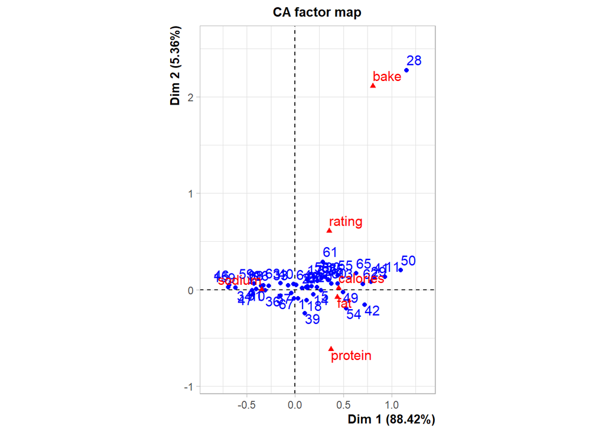

```r
res$col$contrib
```

```
##               Dim 1       Dim 2        Dim 3        Dim 4       Dim 5
## rating    0.3440818 17.07757462 20.099581800 2.629837e+00 59.41444216
## calories 51.5077472  1.22137640  0.620662231 6.781431e+00  0.44820754
## protein   1.3428385 61.87579412 34.148379403 9.245111e-01  0.17818214
## fat       2.9001006  1.42414705 14.285020611 7.851057e+01  0.50785633
## sodium   43.7430601  0.01996782  0.004683564 8.233862e-04  0.02812173
## bake      0.1621718 18.38113999 30.841672391 1.115282e+01 39.42319011
```

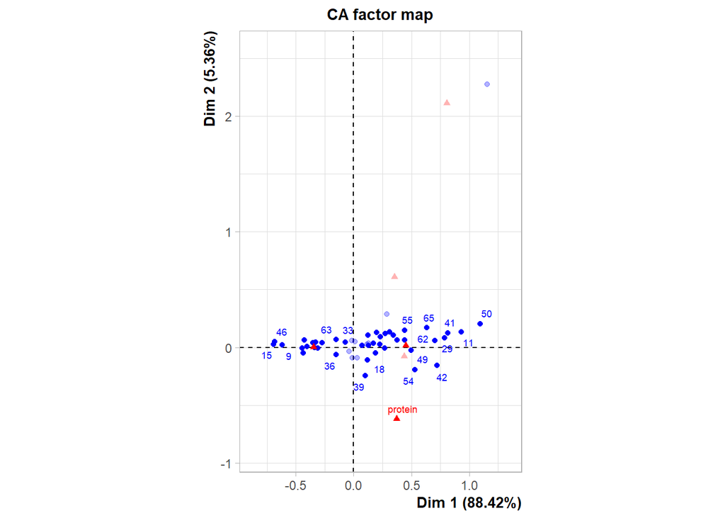

```r
plot(res, selectRow="cos2 0.6",selectCol="cos2 0.6", cex=0.6)
```

Nous avons tracé ici les points les mieux représentés. Les points bleus (donc les plats) proche d’un triangle rouge contient beaucoup de ce composant, ainsi les points autour du triangle fat sont les plats les plus gras. De plus la table des contributions nous indique quelles variables contribuent aux axes trouvés par l’AFC.

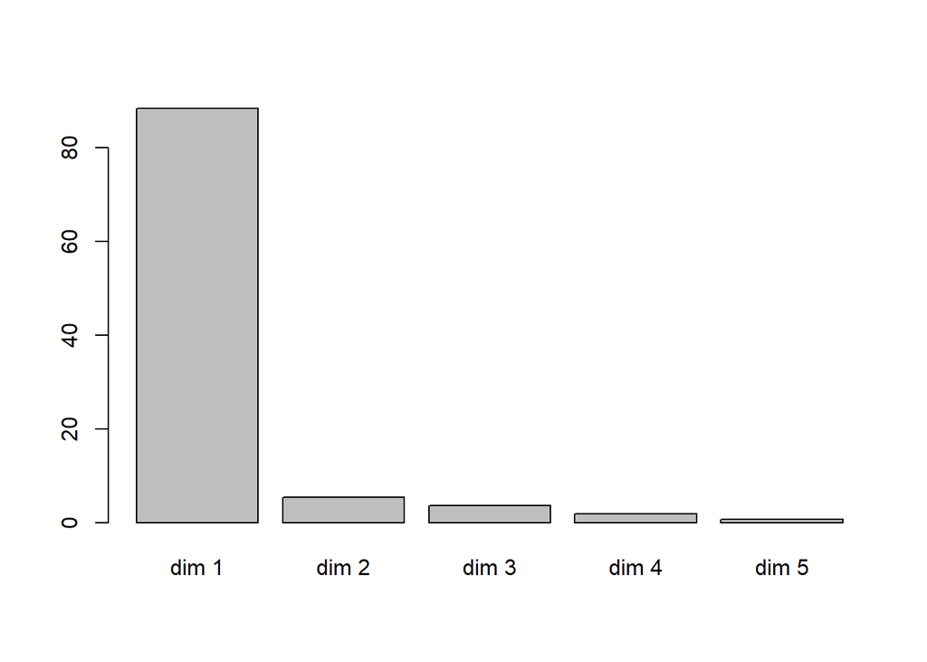

```r
barplot(res$eig[,2])
```

Nous remarquons aussi que la dimension 1 d’écrit 88% de l’inertie. Cette même dimension étant en majorité reliée aux variables calories et sodium.

**Parties 2 : Méthodes de classifications**

Nous allons premièrement utiliser la méthode de classification supervisée de l’analyse discriminante linéaire (LDA) pour expliquer l’appartenance d’un plat à une certaine classe de rating en fonction de ses caractéristiques.

```r
library(MASS)
res = lda(rating ~., data=data)
res
```

```
## Call:
## lda(rating ~ ., data = data)
##
## Prior probabilities of groups:
##           0        1.25       1.875         2.5       3.125        3.75
## 0.081694402 0.007753404 0.005105900 0.025529501 0.073436712 0.260716087
##       4.375           5
## 0.413010590 0.132753404
##
## Group means:
##         calories   protein       fat     sodium  alcoholic       bake
## 0       362.3866  11.23071  17.57793   575.8858 0.19984568 0.09645062
## 1.25    385.9837  14.74797  19.39024   420.6504 0.08943089 0.23577236
## 1.875   369.9506  10.25926  23.58025   647.0370 0.02469136 0.30864198
## 2.5     383.4123  14.00247  20.66914   500.4222 0.03703704 0.24197531
## 3.125  6206.1528 118.53562 345.78627  6426.1914 0.01630901 0.24463519
## 3.75    509.3641  22.24154  29.06165   737.9296 0.01499033 0.25193424
## 4.375 11719.2184  99.33410 670.76862 10980.9071 0.01098901 0.27197802
## 5      6611.4155 326.56980 261.74549  7433.4482 0.07122507 0.16096866
##
## Coefficients of linear discriminants:
##                     LD1           LD2           LD3           LD4           LD5
## calories   1.112811e-06 -1.016917e-04 -0.0003419657 -5.156158e-05  2.006500e-05
## protein   -1.409915e-05  4.282215e-04  0.0006721152  2.921598e-04 -2.458951e-04
## fat       -5.937384e-06  8.974170e-04  0.0032152692  4.725043e-04 -1.077485e-04
## sodium    -6.921825e-07  5.128918e-05  0.0001667369  2.661289e-05 -1.109488e-05
## alcoholic -5.048371e+00 -1.758708e+00  0.4371888704  8.791247e-01 -9.554010e-01
## bake       7.889166e-01 -1.698382e+00  0.3030835699  8.810738e-01 -1.148122e+00
##                     LD6
## calories  -1.448747e-06
## protein    2.127693e-04
## fat        3.052500e-04
## sodium    -1.911664e-05
## alcoholic  7.072581e-03
## bake      -7.716419e-03
##
## Proportion of trace:
##    LD1    LD2    LD3    LD4    LD5    LD6
## 0.9602 0.0309 0.0060 0.0023 0.0005 0.0000
```

Nous pouvons maintenant prédire avec la LDA le rating d’un plat inventé de pur pièce.

```r
#prediction
newdata= data.frame(calories=175,protein=125,fat=51,sodium=140,alcoholic=0,bake=1)

K=nlevels(data$rating)
pred.afd = predict(res, newdata) #par défaut, classe un individi selon la règle du MAP.
pred.afd
```

```
## $class
## [1] 4.375
## Levels: 0 1.25 1.875 2.5 3.125 3.75 4.375 5
##
## $posterior
##            0        1.25       1.875        2.5      3.125      3.75     4.375
## 1 0.02743808 0.007272354 0.006943122 0.02618978 0.07756065 0.2807491 0.4812417
##            5
## 1 0.09260517
##
## $x
##         LD1       LD2       LD3      LD4        LD5        LD6
## 1 0.7901952 -1.174739 0.3732165 0.664599 -0.8732716 0.03453469
```

On remarque ainsi que notre plats appartient à la 7ème classe avec une probabilité à postériori de 48.1% .

Nous pouvons aussi faire de la classification non supervisé avec des méthodes comme CAH et Kmeans.

Commencons pas la classification ascendante hiérarchique (CAH).

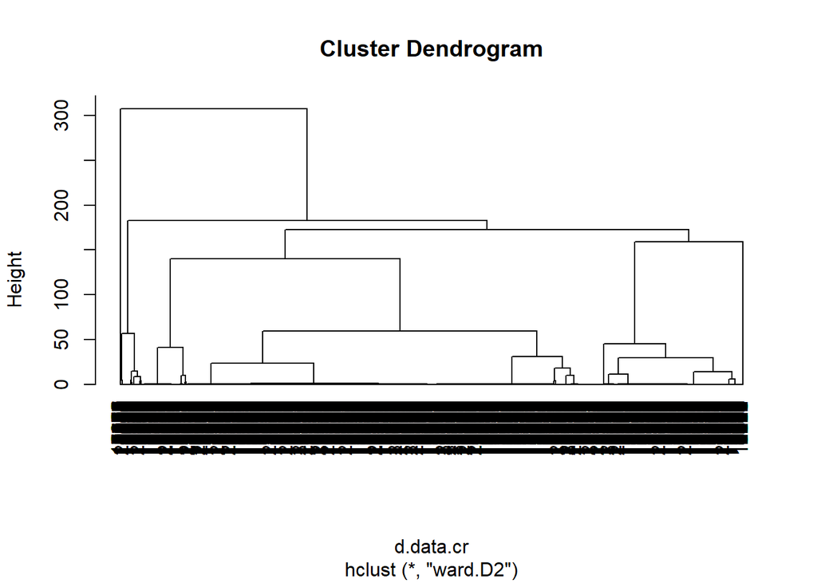

```r
data.cr <- scale(data,center=TRUE, scale=TRUE)
d.data.cr <- dist(data.cr)
#On utilise la mesure de Ward :
cah.ward <- hclust(d.data.cr, method="ward.D2")
#On affichage le dendrogramme :
plot(cah.ward, hang=-1)
```

Le dendrogramme nous permet visuellement de choisir le nombre de classes pour notre classification en élageant notre arbre. Ici nous choississons K = 5 classes.

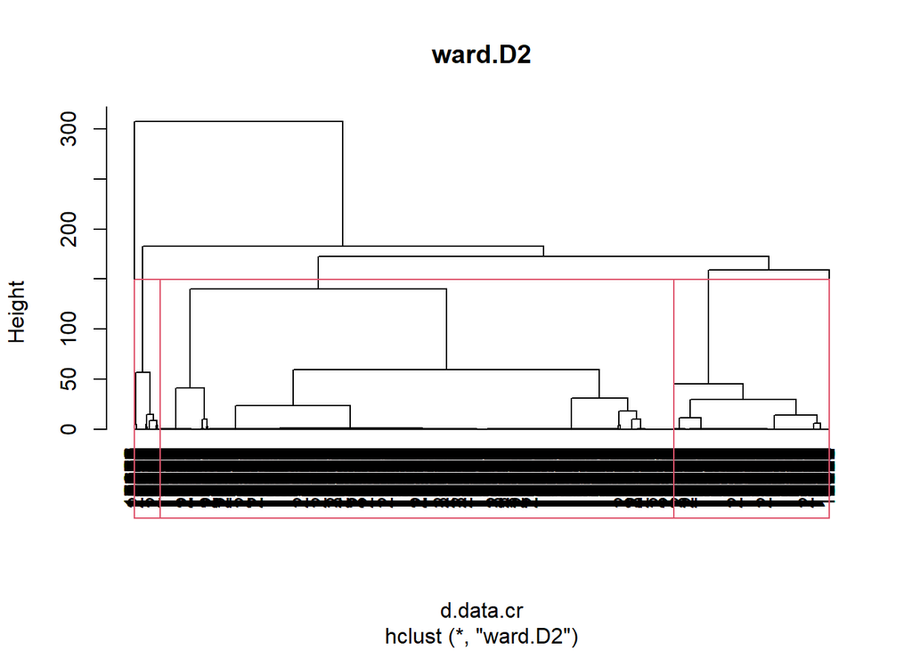

```r
plot(cah.ward, hang =-1,main="ward.D2")
K=5
rect.hclust(cah.ward,K)
```

Nous voyons bien que un élagage en 5 classes permet d’avoir des groupes les plus homogènes et réparties possibles pour notre jeu de données.

```r
groupes.cah <- cutree(cah.ward, K)
table(groupes.cah)
```

```
## groupes.cah
##     1     2     3     4     5
## 11726  3542   590     4     2
```

Cepandant il n’y a que 4 et 2 plats dans les groupes 4 et 5.

```r
Means_groupes <- matrix(NA, nrow=K, ncol=dim(data)[2])
colnames(Means_groupes)=colnames(data)
rownames(Means_groupes) =1:K
for (i in 1:K) Means_groupes[i,]<- colMeans(data[groupes.cah==i,])
round(Means_groupes)
```

```
##   rating calories protein     fat   sodium alcoholic bake
## 1      4      506      25      30      751         0    0
## 2      4     2448      49     136     2606         0    1
## 3      2      225       1       2      165         1    0
## 4      5  6473970  181659  308640  6454126         0    0
## 5      4 30054568  200589 1719521 27623054         0    1
```

Cette table montre les caractéristiques moyennes des plats de chacunes des 5 classes. On remarque tout comme la classification LDA précédente, que les plats avec le rating le plus faibles (classe 3) sont bien les plats peut gras, peu caloriques et avec peu de sodium et souvent alcoolisé. Au contraire la classe avec le rating le plus haut possède des plats gras, caloriques et salée.

Nous pouvons continuer aussi avec la méthodes des Kmeans, pour cela nous devons fixer à l’avance le nombre de classes. Pour cela nous allons nous aider de l’analyse de la CAH ou nous avions pris 5 classes, nous allons donc faire de même pour la méthode des Kmeans.

```r
K=5
kmeans.result <- kmeans(data.cr,centers=K)
kmeans.result$size
```

```
## [1]  3597     2 10501  1174   590
```

```r
kmeans.result <- kmeans(data.cr,centers=K)
kmeans.result$size
```

```
## [1]  1587   158     2  3565 10552
```

On voit que le résultat a changé comparé au précédement, car c’est dépendant de l’initialisation. Il faut donc faire une bonne initialisation avec une CAH ou une stabilisation en lançant plusieurs fois Kmeans. Ici nous allons lancé 1000 méthodes des Kmeans pour que les classes soit stabilisées.

```r
kmeans.result <- kmeans(data.cr,centers=K,nstart=1000)
kmeans.result$size
```

```
## [1]     4  3596  1710 10552     2
```

Nous pouvons maitenant visualiser les dépendances des variables en mettant en couleur les classe trouvées. Cependant avec 5 classes l’analyse devient compliqué.

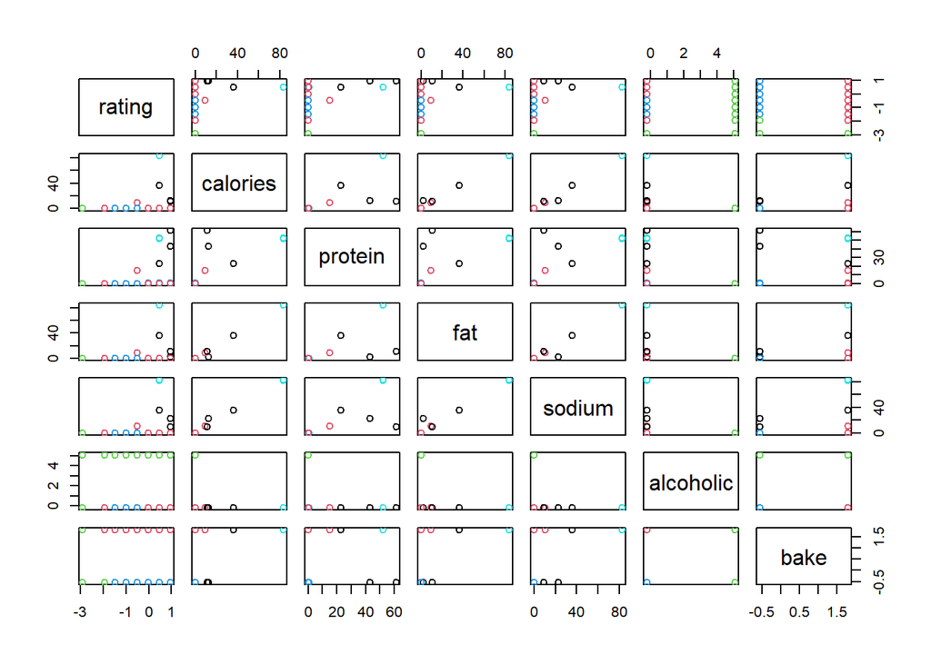

```r
pairs(data.cr, col=kmeans.result$cluster)
```

Nous avons également une autre façon plus graphique pour choisir le nombre de classes K.

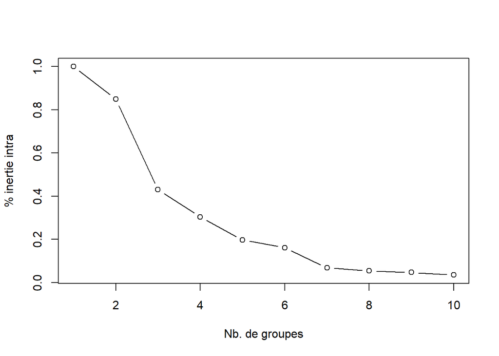

```r
inertie.intra <- rep(0,times=10)
for (k in 1:10)
{
  kmeans.result <- kmeans(data.cr,centers=k,nstart=100)
  inertie.intra[k] <- kmeans.result$tot.withinss/kmeans.result$totss
}
# graphique
plot(1:10,inertie.intra,type="b",xlab="Nb. de groupes",ylab="% inertie intra")
```

Nous pouvons maintenant interprété avec l’ACP

```r
K=5
kmeans.result <- kmeans(data.cr,centers=K,nstart=1000)

data.Avecclasse = cbind.data.frame(data, classe = factor(kmeans.result$cluster))
head(data.Avecclasse)
```

```
##   rating calories protein fat sodium alcoholic bake classe
## 1  2.500      426      30   7    559         0    0      1
## 2  4.375      403      18  23   1439         0    1      3
## 3  3.750      165       6   7    165         0    0      1
## 5  3.125      547      20  32    452         0    1      3
## 6  4.375      948      19  79   1042         0    0      1
## 9  4.375      170       7  10   1272         0    0      1
```

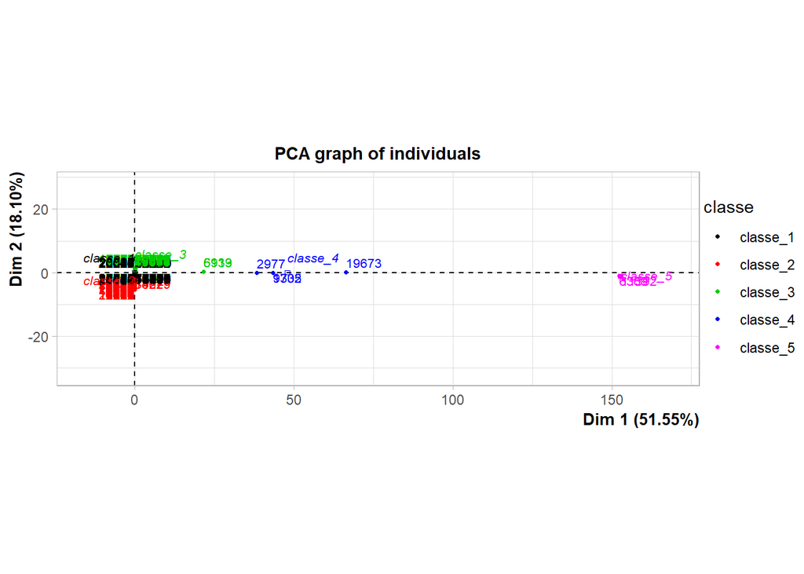

```r
res=PCA(data.Avecclasse,scale.unit=TRUE, quali.sup = 8, graph=FALSE)
plot(res, choix="ind", habillage=8, cex=0.7)
```

**Partie 3 : Modèles de Prédiction**

On réouvre toute les données pour cette partie car il y a quelques convertions a faire.

```r
library(tidyr)
rm(list=ls())
data = read.csv("epi_r.csv", sep =",")
data = data[c(2,3,4,5,6,15,39)]
data = data[data$calories != "",]
data = data[data$protein != "",]
data = data[data$fat != "",]
data = data[data$sodium != "",]
data = drop_na(data)
#on convertie rating en variable qualitative à 5 modalités (entre 0 et 1).
data$rating = as.factor(((data$rating > 1) + (data$rating > 2) + (data$rating > 3) + (data$rating > 4)) / 4)
head(data)
```

```
##   rating calories protein fat sodium alcoholic bake
## 1    0.5      426      30   7    559         0    0
## 2      1      403      18  23   1439         0    1
## 3   0.75      165       6   7    165         0    0
## 5   0.75      547      20  32    452         0    1
## 6      1      948      19  79   1042         0    0
## 9      1      170       7  10   1272         0    0
```

Le but de cette partie est de prédire la variable rating de notre jeu de données a partir des 6 autres variables. Pour cela nous allons entrainé puis tester différents modèles pour voir lequels est le plus adapté.

Pour cela commençons par couper notre jeu de données en 2, un pour l’apprentissage des modèles et un autre pour leurs évaluation.

```r
seed = 1
set.seed(seed)
n = nrow(data)
p = ncol(data)-1
test.ratio = 0.2 # ratio of test/train samples
n.test = round(n*test.ratio)
tr = sample(1:n,n.test)
data.test = data[tr,]
data.train = data[-tr,]
head(data.train)
```

```
##   rating calories protein fat sodium alcoholic bake
## 1    0.5      426      30   7    559         0    0
## 2      1      403      18  23   1439         0    1
## 3   0.75      165       6   7    165         0    0
## 5   0.75      547      20  32    452         0    1
## 6      1      948      19  79   1042         0    0
## 9      1      170       7  10   1272         0    0
```

```r
head(data.test)
```

```
##       rating calories protein fat sodium alcoholic bake
## 1279    0.75      636      31  41   1774         0    0
## 10100   0.75      905      37  52     69         0    0
## 5997       1      452      27  33    220         0    0
## 13062      0       67       2   3    562         0    0
## 16679   0.75      271      12  16    265         0    0
## 12253      1     1148      75  45   1779         0    0
```

Commencons par les modèles LDA et QDA.

```r
library(pROC)
res_lda = lda(rating~., data.train)
pred_lda <- predict(res_lda, data.test, type = "class")

## Table confusion et accuracy :
table(data.test$rating, pred_lda$class)
```

```
##
##           0 0.25  0.5 0.75    1
##   0      58    0    0    0  217
##   0.25    2    0    0    0   44
##   0.5     4    0    0    0   84
##   0.75   14    0    0    0 1035
##   1      45    0    1    0 1669
```

```r
accuracy_lda = mean(data.test$rating == pred_lda$class)
accuracy_lda
```

```
## [1] 0.5442799
```

```r
ROC_lda <- roc(data.test$rating,as.numeric(pred_lda$class))
```

```r
plot(ROC_lda, print.auc=TRUE,  print.auc.y = 0.5)
ROC_lda$auc
```

[output not shown]

```
## Area under the curve: 0.5837
```

```r
#lda version stepwise

library(klaR)
stepwise_lda= stepclass(rating~., data=data.train, method="lda", direction="backward")
```

```
##  `stepwise classification', using 10-fold cross-validated correctness rate of method lda'.
```

```
## 12691 observations of 6 variables in 5 classes; direction: backward
```

```
## stop criterion: improvement less than 5%.
```

```
## correctness rate: 0.54897;  starting variables (6): calories, protein, fat, sodium, alcoholic, bake
##
##  hr.elapsed min.elapsed sec.elapsed
##        0.00        0.00        1.75
```

```r
stepwise_lda
```

```
## method      : lda
## final model : rating ~ calories + protein + fat + sodium + alcoholic + bake
## <environment: 0x00000294e4f51140>
##
## correctness rate = 0.549
```

```r
res_stepwise_lda = lda(stepwise_lda$formula, data=data.train)

pred_stepwise_lda <- predict(res_lda, data.test, type = "class")

## Table confusion et accuracy :
table(data.test$rating, pred_stepwise_lda$class)
```

```
##
##           0 0.25  0.5 0.75    1
##   0      58    0    0    0  217
##   0.25    2    0    0    0   44
##   0.5     4    0    0    0   84
##   0.75   14    0    0    0 1035
##   1      45    0    1    0 1669
```

```r
accuracy_stepwise_lda = mean(data.test$rating == pred_stepwise_lda$class)
accuracy_stepwise_lda
```

```
## [1] 0.5442799
```

```r
ROC_stepwise_lda <- roc(data.test$rating,as.numeric(pred_stepwise_lda$class))
```

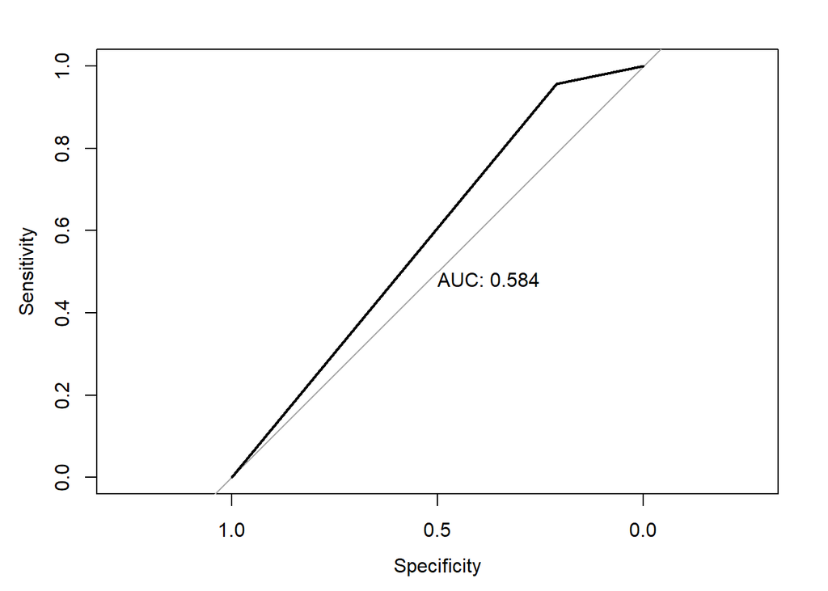

```r
plot(ROC_stepwise_lda, print.auc=TRUE,  print.auc.y = 0.5)
```

```r
ROC_stepwise_lda$auc
```

```
## Area under the curve: 0.5837
```

```r
accuracy_lda = max(accuracy_lda, accuracy_stepwise_lda)

#QDA

res_qda=qda(rating~., data.train)

#prediction:
pred_qda = predict(res_qda, data.test, type = "class")

## Table confusion et accuracy :
table(data.test$rating, pred_qda$class)
```

```
##
##           0 0.25  0.5 0.75    1
##   0      70    5  194    3    3
##   0.25    4    2   39    1    0
##   0.5     7    2   78    1    0
##   0.75  106   27  883   24    9
##   1     193   44 1390   57   31
```

```r
accuracy_qda = mean(data.test$rating == pred_qda$class)
accuracy_qda
```

```
## [1] 0.06460763
```

```r
ROC_qda <- roc(data.test$rating, as.numeric(pred_qda$class))
```

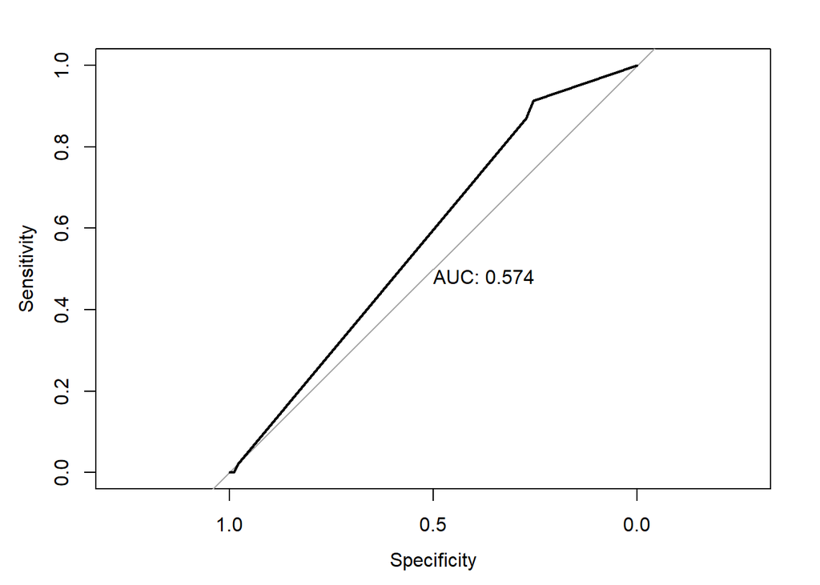

```r
plot(ROC_qda, print.auc=TRUE,  print.auc.y = 0.5)
```

```r
ROC_qda$auc
```

```
## Area under the curve: 0.5742
```

Nous avons effectué la LDA de deux manières différentes mais comme le montre leurs graphiques leurs résultats sont équivalents. On cherche a avoir l’aire en dessous de la courbe ROC le plus proche de 1 possible, pour l’instant ca n’est pas trop le cas, nous allons voir si d’autre modèle font mieu.

Mise en place du modèle CART

```r
library(rpart)
library(rpart.plot)
arbre = rpart(rating~.,data.train)
cp.opt <- arbre$cptable[which.min(arbre$cptable[, "xerror"]), "CP"]
arbre.opt <- prune(arbre,cp=cp.opt)

## prédiction :
pred_arbre = predict(arbre.opt, data.test, type = "class")
## Table confusion et accuracy :
table(data.test$rating, pred_arbre)
```

```
##       pred_arbre
##           0 0.25  0.5 0.75    1
##   0       0    0    0    0  275
##   0.25    0    0    0    0   46
##   0.5     0    0    0    0   88
##   0.75    0    0    0    0 1049
##   1       0    0    0    0 1715
```

```r
accuracy_cart = mean(data.test$rating == pred_arbre)
accuracy_cart
```

```
## [1] 0.540498
```

```r
## aire sous courbe ROC
pred_cart = predict(arbre.opt, data.test, type="prob")[,2]
ROC_cart <- roc(data.test$rating, pred_cart)
ROC_cart$auc
```

```
## Area under the curve: 0.5
```

On a une aire ROC de 0.5 se qui est très proche des résultats des méthodes LDA et QDA.

Essayons à présent le modèle random forest.

```r
library(randomForest)
fit_RF <- randomForest(rating~.,data.train)
fit_RF
```

```
##
## Call:
##  randomForest(formula = rating ~ ., data = data.train)
##                Type of random forest: classification
##                      Number of trees: 500
## No. of variables tried at each split: 2
##
##         OOB estimate of  error rate: 42.87%
## Confusion matrix:
##        0 0.25 0.5 0.75    1 class.error
## 0    165    0   0   46  810  0.83839373
## 0.25   6    5   0   19  128  0.96835443
## 0.5    9    0   4   36  268  0.98738170
## 0.75  29    0   1  600 3622  0.85888993
## 1     80    0   0  387 6476  0.06726199
```

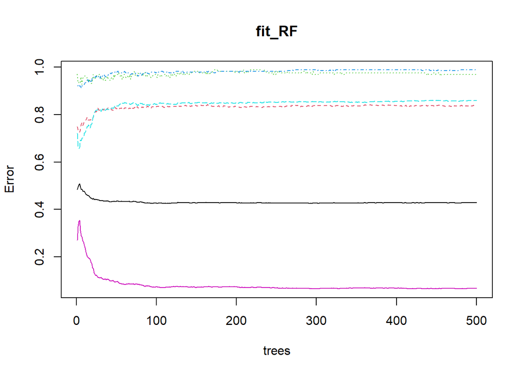

```r
plot(fit_RF)
```

```r
## prédiction :
pred_rf = predict(fit_RF, data.test, type="class")

## Table confusion et accuracy :
table(data.test$rating, pred_rf)
```

```
##       pred_rf
##           0 0.25  0.5 0.75    1
##   0      57    0    0    9  209
##   0.25    1    2    0    4   39
##   0.5     1    0    3    4   80
##   0.75    8    0    1  147  893
##   1      21    0    0   63 1631
```

```r
accuracy_RF = mean(data.test$rating == pred_rf)
accuracy_RF
```

```
## [1] 0.5798928
```

```r
## aire sous courbe ROC
pred_RF = predict(fit_RF, data.test, type="prob")[,2]
ROC_RF <- roc(data.test$rating, pred_RF)
ROC_RF$auc
```

```
## Area under the curve: 0.6358
```

Passons au modèle de régression logistique

```r
### Modèle
logit.train <- glm(rating ~ ., family = binomial , data=data.train)
# régression logistique Lasso
library(glmnet)
```

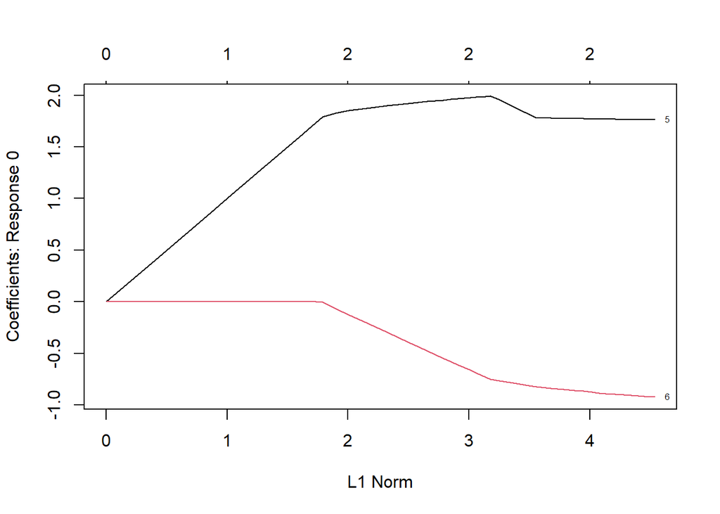

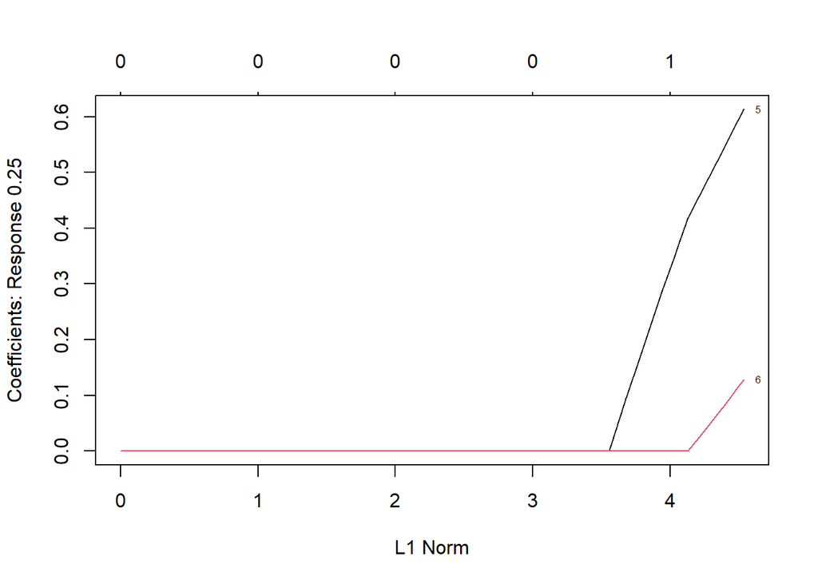

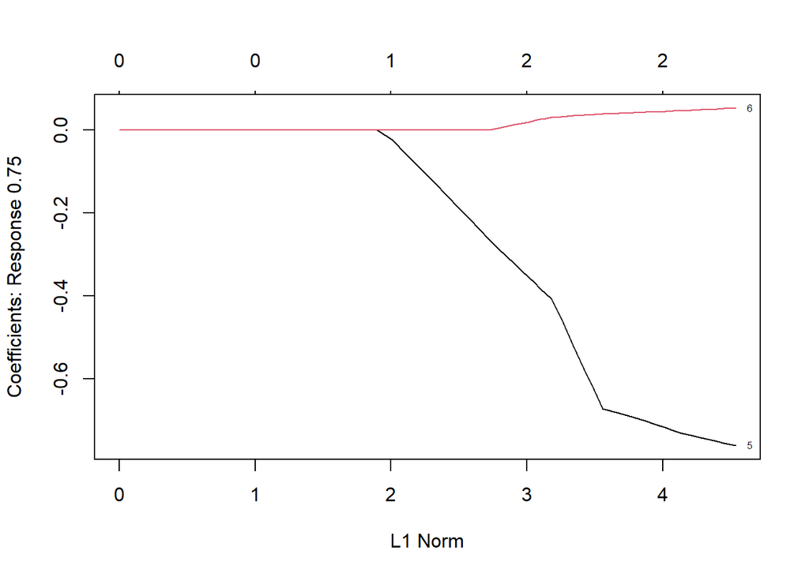

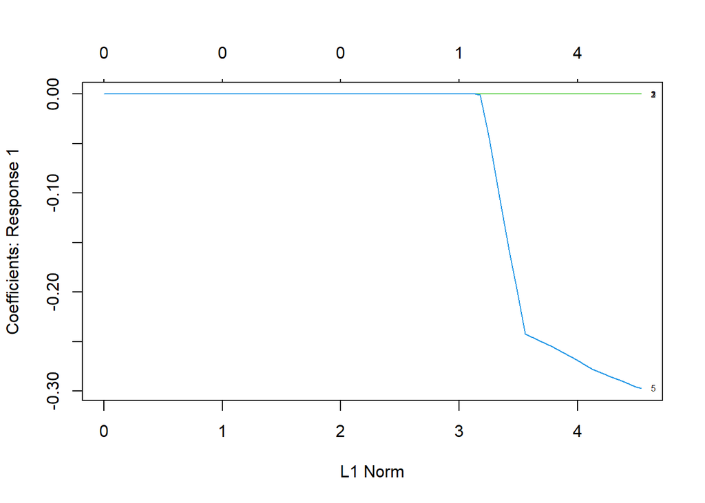

```r
res_Lasso <- glmnet(as.matrix(data.train[,-1]),data.train$rating, family='multinomial')
plot(res_Lasso, label = TRUE)  # en abscisse : norme des coefficients
```

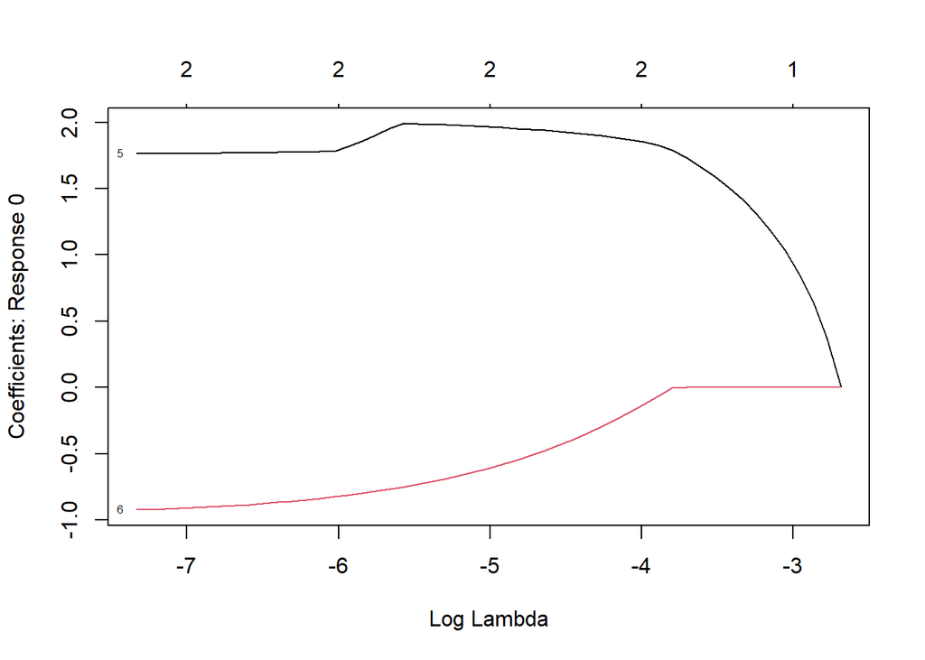

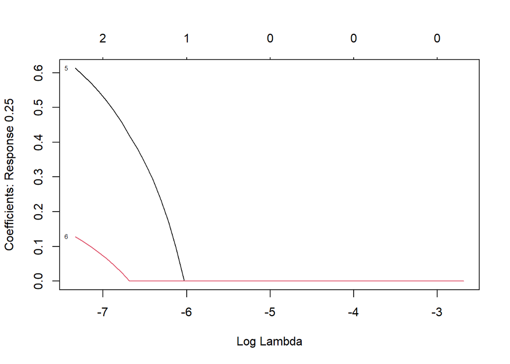

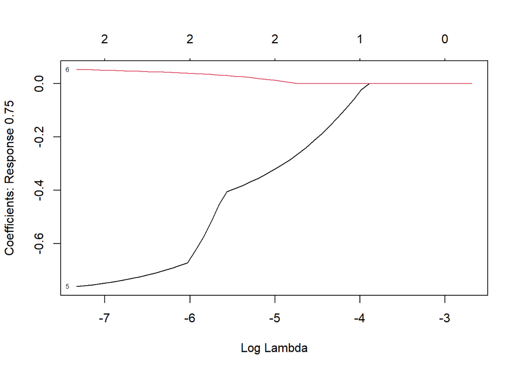

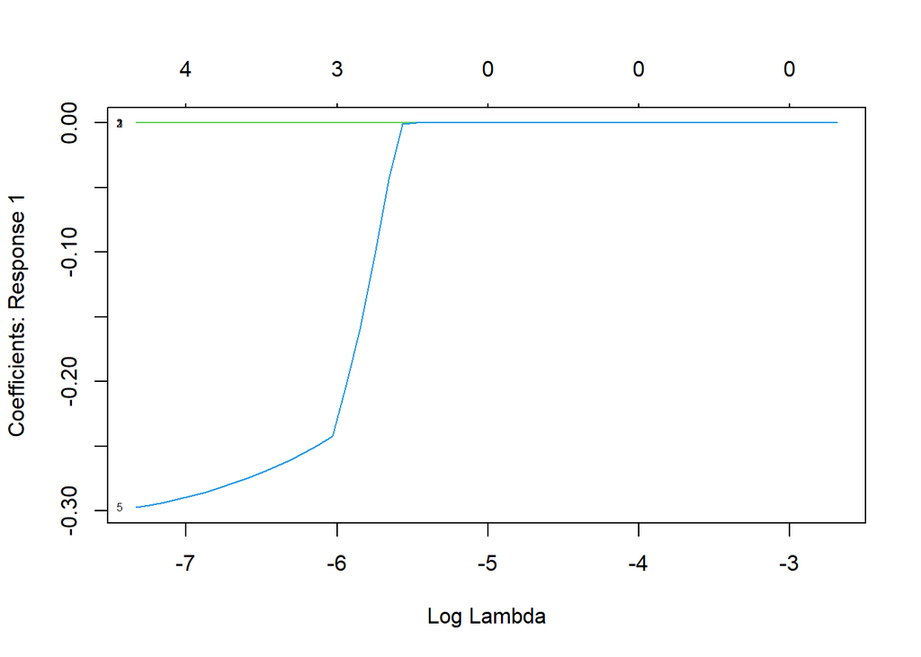

```r
plot(res_Lasso, xvar = "lambda", label = TRUE) # en abscisse : log(lambda)
```

```r
#sum(coef(res_Lasso, s=exp(-7))!=0)


cvLasso <- cv.glmnet(as.matrix(data.train[,-1]),data.train$rating,family="multinomial", type.measure = "class")
```

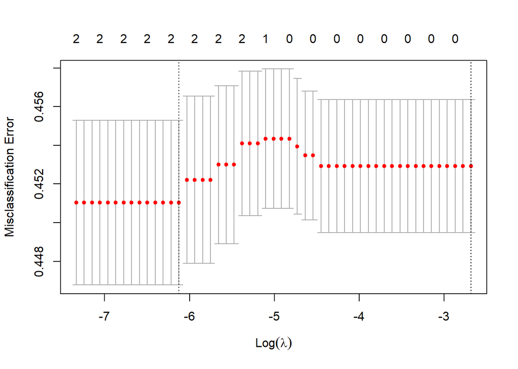

```r
plot(cvLasso)
```

```r
cvLasso$lambda.min
```

```
## [1] 0.002188346
```

```r
coef(res_Lasso, s=cvLasso$lambda.min)
```

```
## $`0`
## 7 x 1 sparse Matrix of class "dgCMatrix"
##                       1
## (Intercept) -0.08559467
## calories     .
## protein      .
## fat          .
## sodium       .
## alcoholic    1.77903107
## bake        -0.83625022
##
## $`0.25`
## 7 x 1 sparse Matrix of class "dgCMatrix"
##                       1
## (Intercept) -1.92745068
## calories     .
## protein      .
## fat          .
## sodium       .
## alcoholic    0.09367759
## bake         .
##
## $`0.5`
## 7 x 1 sparse Matrix of class "dgCMatrix"
##                     1
## (Intercept) -1.227873
## calories     .
## protein      .
## fat          .
## sodium       .
## alcoholic    .
## bake         .
##
## $`0.75`
## 7 x 1 sparse Matrix of class "dgCMatrix"
##                       1
## (Intercept)  1.37516365
## calories     .
## protein      .
## fat          .
## sodium       .
## alcoholic   -0.68279486
## bake         0.03994453
##
## $`1`
## 7 x 1 sparse Matrix of class "dgCMatrix"
##                         1
## (Intercept)  1.865754e+00
## calories     2.255873e-09
## protein      3.267468e-06
## fat          3.612021e-07
## sodium       .
## alcoholic   -2.487966e-01
## bake         .
```

```r
#prédiction
class_logit_lasso=predict(cvLasso, newx = as.matrix(data.test[,-1]), s = 'lambda.min', type = "class")

#Table de confusion et accuracy
accuracy_logit_lasso = mean(data.test$rating == class_logit_lasso)
#accuracy_logit_lasso

#courbe ROC
pred_logit_lasso_tmp = predict(cvLasso, newx = as.matrix(data.test[,-1]), s = 'lambda.min', type = "response")

pred_logit_lasso = 1:n.test
for(i in 1:n.test)
{
  pred_logit_lasso[i] = pred_logit_lasso_tmp[i,2,] * 0.25 + pred_logit_lasso_tmp[i,3,] * 0.5 + pred_logit_lasso_tmp[i,4,] * 0.75 + pred_logit_lasso_tmp[i,5,] * 1
}

#pred_logit_lasso
ROC_logit_lasso = roc(data.test$rating, pred_logit_lasso)
ROC_logit_lasso$auc
```

```
## Area under the curve: 0.6701
```

Les graphiques des coefficients en fonction de log(lambda) correspond à un chemin de régularisation du Lasso. Le chemin cherche a augmenter lamba pour réduire le nombre de coefficients non nuls. A la fin, les coefficients non nuls sont les variables significatives.

On choisit lambda par cross-validation, c’est à dire la valeur de lambda qui minimise l’erreur de classification.

Nous rassemblons tout ces graphiques pour les comparer.

```r
result=matrix(NA, ncol=5, nrow=2)
rownames(result)=c('accuracy', 'AUC')
colnames(result)=c('lda', 'qda', 'cart', 'RF', 'logit_lasso')
result[1,]= c(accuracy_lda, accuracy_qda, accuracy_cart, accuracy_RF, accuracy_logit_lasso)
result[2,]=c(ROC_lda$auc, ROC_qda$auc, ROC_cart$auc, ROC_RF$auc, ROC_logit_lasso$auc)
result
```

```
##                lda        qda     cart        RF logit_lasso
## accuracy 0.5442799 0.06460763 0.540498 0.5798928   0.5442799
## AUC      0.5837154 0.57418972 0.500000 0.6358103   0.6701186
```

```r
apply(result,1, which.max )
```

```
## accuracy      AUC
##        4        5
```

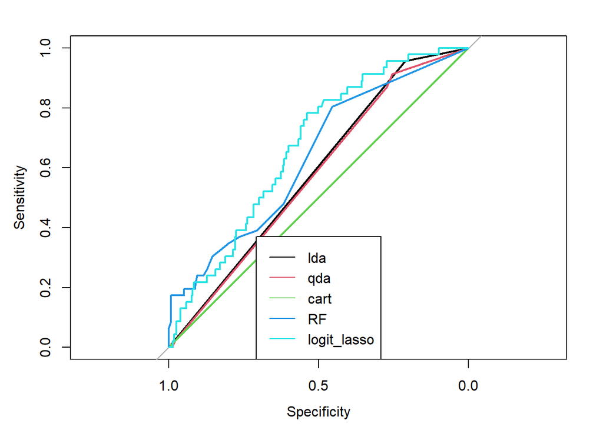

```r
plot(ROC_lda, xlim=c(1,0))
plot(ROC_qda, add=TRUE, col=2)
plot(ROC_cart, add=TRUE, col=3)
plot(ROC_RF, add=TRUE, col=4)
plot(ROC_logit_lasso, add=TRUE, col=5)
legend('bottom', col=1:5, paste(c('lda', 'qda', 'cart', 'RF', 'logit_lasso')), lwd=1)
```